# Data624 - Project2

Joseph Elikishvili

November 13, 2017

## Data Exploration

We will load the data into a dataframe and get started

```r
library(missForest)
library(corrgram)
library('caret')

df = read.csv("https://github.com/ChristopheHunt/CUNY-DATA624/raw/master/data/StudentData.csv", header = TRUE)
```

First we will examine the training dataset we want to see how many predictor variables we are dealing with and if we are missing any data

```r
dim(df)
```

```
## [1] 2571   33
```

Looks like we have a total of 32 predictor variables and a target variable. Next we will check for any missing data

```r
summary(df)
```

```
##  Brand.Code  Carb.Volume     Fill.Ounces      PC.Volume
##   : 120     Min.   :5.040   Min.   :23.63   Min.   :0.07933
##  A: 293     1st Qu.:5.293   1st Qu.:23.92   1st Qu.:0.23917
##  B:1239     Median :5.347   Median :23.97   Median :0.27133
##  C: 304     Mean   :5.370   Mean   :23.97   Mean   :0.27712
##  D: 615     3rd Qu.:5.453   3rd Qu.:24.03   3rd Qu.:0.31200
##             Max.   :5.700   Max.   :24.32   Max.   :0.47800
##             NA's   :10      NA's   :38      NA's   :39
##  Carb.Pressure     Carb.Temp          PSC             PSC.Fill
##  Min.   :57.00   Min.   :128.6   Min.   :0.00200   Min.   :0.0000
##  1st Qu.:65.60   1st Qu.:138.4   1st Qu.:0.04800   1st Qu.:0.1000
##  Median :68.20   Median :140.8   Median :0.07600   Median :0.1800
##  Mean   :68.19   Mean   :141.1   Mean   :0.08457   Mean   :0.1954
##  3rd Qu.:70.60   3rd Qu.:143.8   3rd Qu.:0.11200   3rd Qu.:0.2600
##  Max.   :79.40   Max.   :154.0   Max.   :0.27000   Max.   :0.6200
##  NA's   :27      NA's   :26      NA's   :33        NA's   :23
##     PSC.CO2           Mnf.Flow       Carb.Pressure1  Fill.Pressure
##  Min.   :0.00000   Min.   :-100.20   Min.   :105.6   Min.   :34.60
##  1st Qu.:0.02000   1st Qu.:-100.00   1st Qu.:119.0   1st Qu.:46.00
##  Median :0.04000   Median :  65.20   Median :123.2   Median :46.40
##  Mean   :0.05641   Mean   :  24.57   Mean   :122.6   Mean   :47.92
##  3rd Qu.:0.08000   3rd Qu.: 140.80   3rd Qu.:125.4   3rd Qu.:50.00
##  Max.   :0.24000   Max.   : 229.40   Max.   :140.2   Max.   :60.40
##  NA's   :39        NA's   :2         NA's   :32      NA's   :22
##  Hyd.Pressure1   Hyd.Pressure2   Hyd.Pressure3   Hyd.Pressure4
##  Min.   :-0.80   Min.   : 0.00   Min.   :-1.20   Min.   : 52.00
##  1st Qu.: 0.00   1st Qu.: 0.00   1st Qu.: 0.00   1st Qu.: 86.00
##  Median :11.40   Median :28.60   Median :27.60   Median : 96.00
##  Mean   :12.44   Mean   :20.96   Mean   :20.46   Mean   : 96.29
##  3rd Qu.:20.20   3rd Qu.:34.60   3rd Qu.:33.40   3rd Qu.:102.00
##  Max.   :58.00   Max.   :59.40   Max.   :50.00   Max.   :142.00
##  NA's   :11      NA's   :15      NA's   :15      NA's   :30
##   Filler.Level    Filler.Speed   Temperature      Usage.cont
##  Min.   : 55.8   Min.   : 998   Min.   :63.60   Min.   :12.08
##  1st Qu.: 98.3   1st Qu.:3888   1st Qu.:65.20   1st Qu.:18.36
##  Median :118.4   Median :3982   Median :65.60   Median :21.79
##  Mean   :109.3   Mean   :3687   Mean   :65.97   Mean   :20.99
##  3rd Qu.:120.0   3rd Qu.:3998   3rd Qu.:66.40   3rd Qu.:23.75
##  Max.   :161.2   Max.   :4030   Max.   :76.20   Max.   :25.90
##  NA's   :20      NA's   :57     NA's   :14      NA's   :5
```

[output cut: 17 more lines]

```
##  Min.   :44.00     Min.   :140.8   Min.   :5.280   Min.   :4.960
##  1st Qu.:46.00     1st Qu.:142.2   1st Qu.:6.540   1st Qu.:5.340
##  Median :46.00     Median :142.6   Median :6.560   Median :5.400
##  Mean   :47.62     Mean   :142.8   Mean   :6.897   Mean   :5.437
##  3rd Qu.:50.00     3rd Qu.:143.0   3rd Qu.:7.240   3rd Qu.:5.540
##  Max.   :52.00     Max.   :148.2   Max.   :8.620   Max.   :6.060
##  NA's   :12                        NA's   :9       NA's   :10
##   Balling.Lvl
##  Min.   :0.00
##  1st Qu.:1.38
##  Median :1.48
##  Mean   :2.05
##  3rd Qu.:3.14
##  Max.   :3.66
##  NA's   :1
```

It appears we have missing data for pretty much every variable. Our target variable has 4 missing values out of 2571, so we will remove the data from those instead of imputing the missing values for the target variable.

```r
df = subset(df, !is.na(PH))
dim(df)
```

```
## [1] 2567   33
```

Next we will use the missForest library to impute the missing variable of the predictor variables

```r
df_imp = missForest(df)
```

```
##   missForest iteration 1 in progress...done!
##   missForest iteration 2 in progress...done!
##   missForest iteration 3 in progress...done!
##   missForest iteration 4 in progress...done!
##   missForest iteration 5 in progress...done!
```

```r
df_imputed = df_imp$ximp
```

Now we are ready to move on and review the predictor variables and attemp to reduce the number of predictor variables. We will use corrgram library to review the corelation between the variables and find the highly corelated ones that can be reduced.

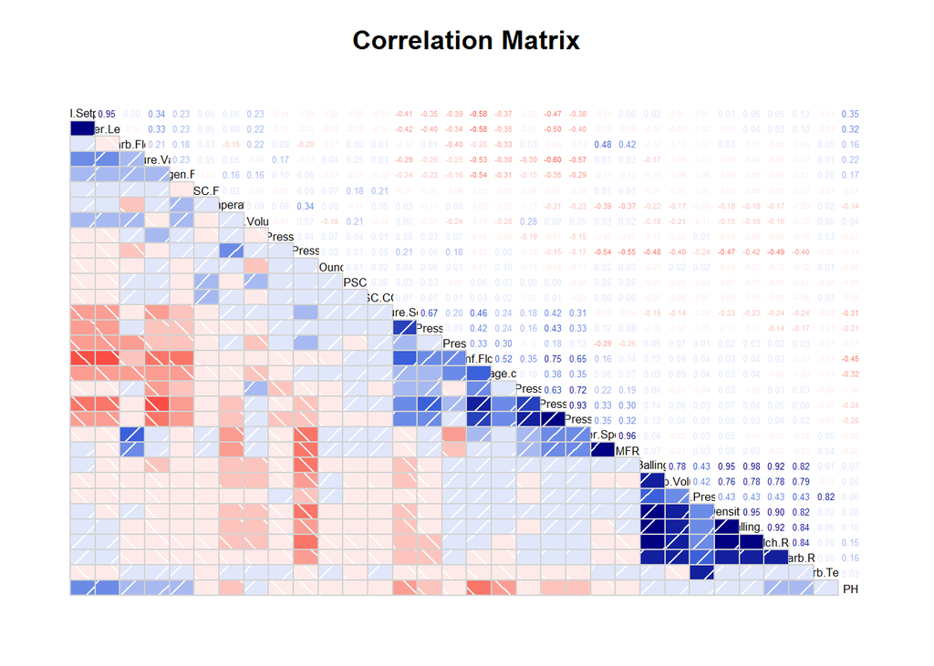

```r
corrgram(df_imputed, order=TRUE,
         upper.panel=panel.cor, main="Correlation Matrix")
```

Before we proceed we will also remove Brand.Code as it is the only categorical vaiable and has a lot of empty non Na values.

```r
df_imputed$Brand.Code = NULL
```

Next we will will reduce our dataset and remove pairs that have corelation above 0.60

```r
#https://stackoverflow.com/questions/18275639/remove-highly-correlated-variables

df2 = cor(df_imputed)
hc = findCorrelation(df2, cutoff=0.6)
hc = sort(hc)
reduced_Data = df_imputed[,-c(hc)]
```

Lets review the dimention of the dataset and recreate correlation matrix

```r
dim(reduced_Data)
```

```
## [1] 2567   20
```

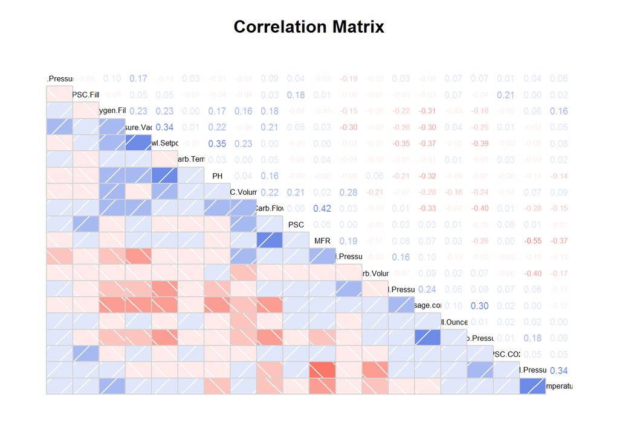

```r
corrgram(reduced_Data, order=TRUE,
         upper.panel=panel.cor, main="Correlation Matrix")
```